# Taller 1 Series de Tiempo

Diego Torres & Jhon Fonseca

25 de marzo de 2020

### **Estudio de Mercadeo del Petroleo**

Se tiene una base de datos mensual entre enero de 1992 y enero de 2020 con informacion relacionada a la cantidad de toneladas metricas de petroleo exportados mensualmente durante este intervalo de años por el pais. La descripción de las variables es la siguiente:

**fecha:** el año y el mes de cada observacion.  
**ton.metricas** el numero de toneladas metricas de petroleo exportadas por el pais mensualmente.

A continuación, un resumen de los datos.

```
## 'data.frame':    337 obs. of  2 variables:
##  $ fecha       : Factor w/ 337 levels "abr-00","abr-01",..: 106 134 218 21 246 190 162 49 330 302 ...
##  $ ton.metricas: int  1327509 1013885 1349665 1110176 1128888 770133 1165882 1181742 1030560 1192537 ...
## NULL
```

```
##      fecha      ton.metricas
##  abr-00 :  1   Min.   : 474294
##  abr-01 :  1   1st Qu.:1478867
##  abr-02 :  1   Median :1987773
##  abr-03 :  1   Mean   :2332446
##  abr-04 :  1   3rd Qu.:3329994
##  abr-05 :  1   Max.   :4593090
##  (Other):331
```

A continuación, los paquetes que se usaran en el proyecto:

```r
library(TSA)
library(tseries)
library(forecast)
library(ggplot2)
library(ggfortify)
```

Ahora bien, procederemos a realizar el modelo de series de tiempo de la variable numerica mediante la funcion `ts()`

```r
ton.ts <- ts(ton$ton.metricas, start = c(1992,1), frequency = 12)
str(ton.ts)
```

```
##  Time-Series [1:337] from 1992 to 2020: 1327509 1013885 1349665 1110176 1128888 770133 1165882 1181742 1030560 1192537 ...
```

```r
head(ton.ts, 30)
```

```
##          Jan     Feb     Mar     Apr     May     Jun     Jul     Aug
## 1992 1327509 1013885 1349665 1110176 1128888  770133 1165882 1181742
## 1993 1276354 1045979 1067458 1137463 1070293 1197147 1054852  802599
## 1994 1182858 1243733 1148188 1094655  673519 1011040
##          Sep     Oct     Nov     Dec
## 1992 1030560 1192537  474294  720154
## 1993 1102519 1350101  996133  661010
## 1994
```

Ahora, observaremos la tendencia de estos datos mediante una evaluación de un modelo de regresion simple

```r
modelo <- lm(ton.ts ~ time(ton.ts))
summary(modelo)
```

```
##
## Call:
## lm(formula = ton.ts ~ time(ton.ts))
##
## Residuals:
##      Min       1Q   Median       3Q      Max
## -1418623  -544092    14138   492638  1661949
##
## Coefficients:
##                Estimate Std. Error t value Pr(>|t|)
## (Intercept)  -195663337    8665740  -22.58   <2e-16 ***
## time(ton.ts)      98702       4320   22.85   <2e-16 ***
## ---
## Signif. codes:  0 '***' 0.001 '**' 0.01 '*' 0.05 '.' 0.1 ' ' 1
##
## Residual standard error: 642900 on 335 degrees of freedom
## Multiple R-squared:  0.6091, Adjusted R-squared:  0.608
## F-statistic:   522 on 1 and 335 DF,  p-value: < 2.2e-16
```

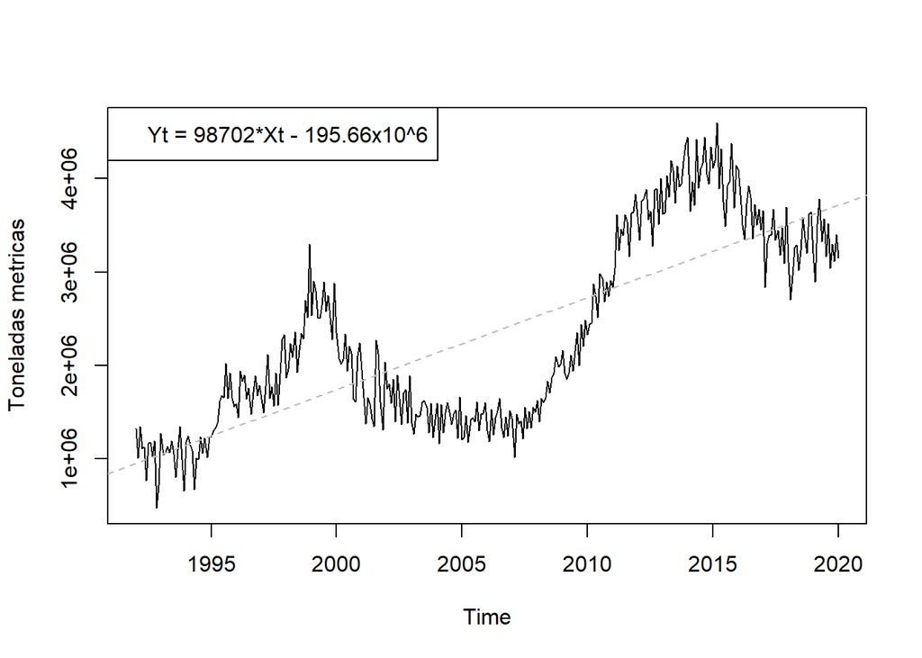

```r
plot(ton.ts,type='line',ylab='Toneladas metricas')
abline(modelo, lty = "dashed", col = "grey")
legend(x = "topleft", y = "Yt = 98702*Xt - 195.66x10^6")
```

H0: la serie no es estacionaria.  
H1: la serie es estacionaria.

```r
adf.test(ton.ts)
```

```
##
##  Augmented Dickey-Fuller Test
##
## data:  ton.ts
## Dickey-Fuller = -1.129, Lag order = 6, p-value = 0.9168
## alternative hypothesis: stationary
```

Al ser el p-valor mayor al nivel de significancia de 95%, entonces se acepta la hipotesis nula de que la serie no es estacionaria.

Ahora bien, sabiendo que la serie trabajada no es estacionaria, haremos un breve analisis de cada uno de sus componentes. Iniciaremos con un plot sencillo.

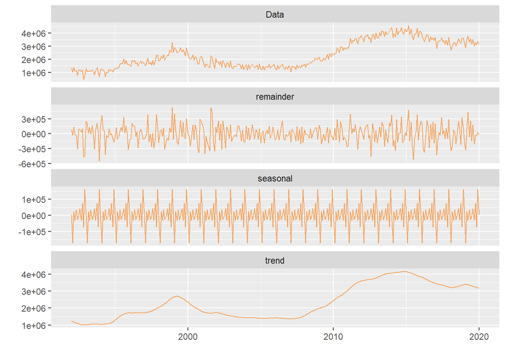

```r
autoplot(stl(ton.ts, s.window = 'periodic'), ts.colour = "sandybrown")
```

Veremos el autocorrelograma

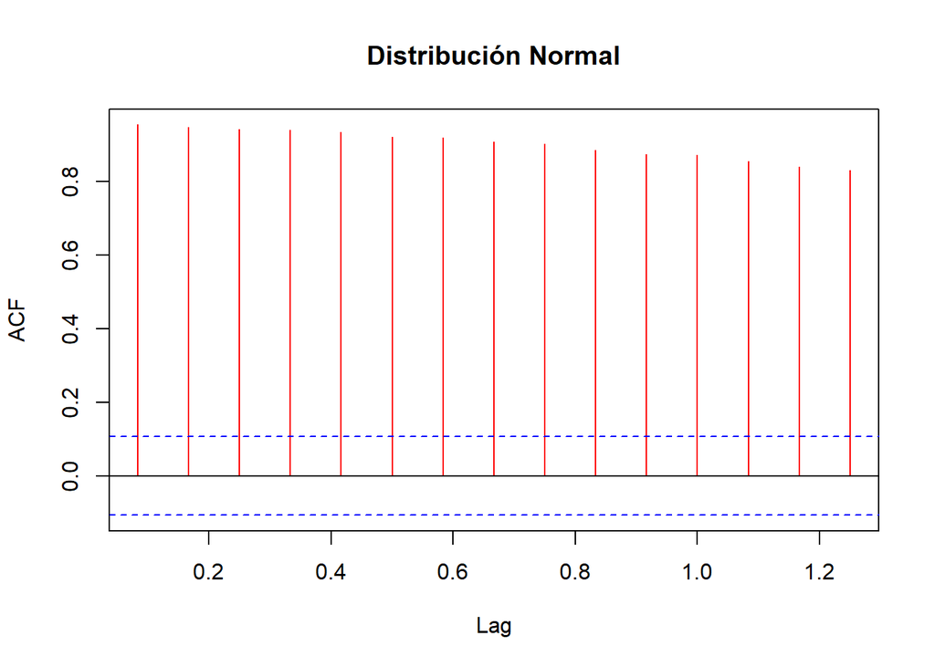

```r
acf(ton.ts, main = "Distribución Normal",col="red", lag.max = 15)
```

H0 = Es un ruido blanco. H1 = NO es un ruido blanco.

```
##
##  Box-Pierce test
##
## data:  ton.ts
## X-squared = 306.92, df = 1, p-value < 2.2e-16
```

En este caso el p-valor es muy inferior al nivel de significancia de 95%, por lo tanto se rechaza la hipotesis de que la serie analizada pueda ser ruido blanco